# Vinho Verde Wine Analysis

Evan Jones

October 02, 2020

# 1 Overview

The purpose of this analysis is to develop an explanatory model to predict the quality of “Vinho Verde” wine. “Vinho Verde” is a classification for wine that is produced from grapes only grown in the northwest regions of Portugal. Currently, Portugal has issues with illegal wine manufacturing. As a solution, they require all wine batches to be tasted for quality by a subjective wine expert. This expert gives a rating to a batch of wine which is then bottled and sold. This rating is essential to the wine selling process. Therefore, it’s in a winery’s best interest to as closely predict the rating of this wine as possible.

This dataset comes from the University of California, Irvine (UCI) Machine Learning Dataset Library (Cortez et al. 2009). It contains individual observations of physiochemical properties of red and white wines from different wineries in the region. This dataset additionally contains the subjective wine expert rating that the batch received.

As a result of this analysis, an explanatory model was created to estimate “Vinho Verde” wine quality. By using this model, technicians working at these wineries will be able to input their daily measurements of physiochemical properties and receive an indication as to what the overall batch quality will look like once it is graded by subjective wine experts.

# 2 Data Description

There are 13 total variables in the dataset. Below is a complete listing of the variables, their data types, unit of measurement, and brief description.

[output not shown]

# 3 Analysis

## 3.1 Environment Information

This analysis was completed in an R 4.0.2 environment on a 64-bit version of Windows 10. The following packages were used for analysis:

1. tidyverse (1.3.0) - used for data wrangling and manipulation
2. DataExplorer (0.8.1) - used for exploratory data analysis
3. caret (6.0-86) - used for formula calculations (e.g. RMSE)

## 3.2 Preprocessing

The following steps were applied in order to prepare the data. Please note that any of the underlying R code can be viewed by hitting the code button on the right in order to reproduce the analysis.

1. The most recent copy of the dataset was read in from the UCI archives

```r
# Read in datasets from UCI website
df_white <- read.csv2("https://archive.ics.uci.edu/ml/machine-learning-databases/wine-quality/winequality-white.csv")
df_red <- read.csv2("https://archive.ics.uci.edu/ml/machine-learning-databases/wine-quality/winequality-red.csv")

# Union datasets
df_white$color <- "White"
df_red$color <- "Red"

df <- union_all(df_white, df_red)

# Remove old datasets
rm(df_red, df_white)
```

2. Variables were renamed to fit proper naming conventions for snake case

```r
# Rename columns to snake case
df <- df %>%
  rename(fixed_acidity = fixed.acidity,
         volatile_acidity = volatile.acidity,
         citric_acid = citric.acid,
         residual_sugar = residual.sugar,
         free_sulfur_dioxide = free.sulfur.dioxide,
         total_sulfur_dioxide = total.sulfur.dioxide
         )
```

3. Incorrect variable types were converted to the correct types that are listed in the data description section above

```r
# Identify column data types
df.numeric = c("fixed_acidity","volatile_acidity", "citric_acid", "residual_sugar", "chlorides", "density", "pH", "sulphates", "alcohol", "quality")
df.int = c("free_sulfur_dioxide", "total_sulfur_dioxide")
df.factor = c("color")

df[df.numeric] <- lapply(df[df.numeric], as.numeric)
df[df.int] <- lapply(df[df.int], as.integer)
df[df.factor] <- lapply(df[df.factor], as.factor)

rm(df.numeric, df.int, df.factor)
```

4. The wine color was releveled so that white wine would act as the base level

```r
# relevel color base as white (red wines are generally more premium)
df$color <- df$color %>% relevel(ref = "White")
```

## 3.3 Exploratory Analysis

**Amount of Missing values**

There are no missing values in the dataset. It is considered 100% complete.

**Check for Multicollinearity**

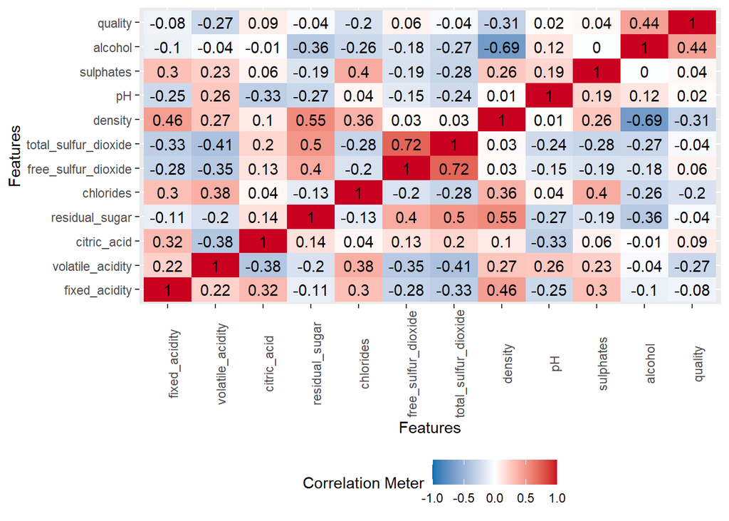

```r
# Plot correlation matrix of all numeric variables
plot_correlation(df, type = "c")
```

Looking at a correlation matrix of the quantitative variables in the model, there are two values that stand out as potentially concerning. Alcohol content has a moderately strong negative correlation with density. Additionally, free sulfur dioxide has a moderately strong positive correlation with total sulfur dioxide.

**Value Range Plots**

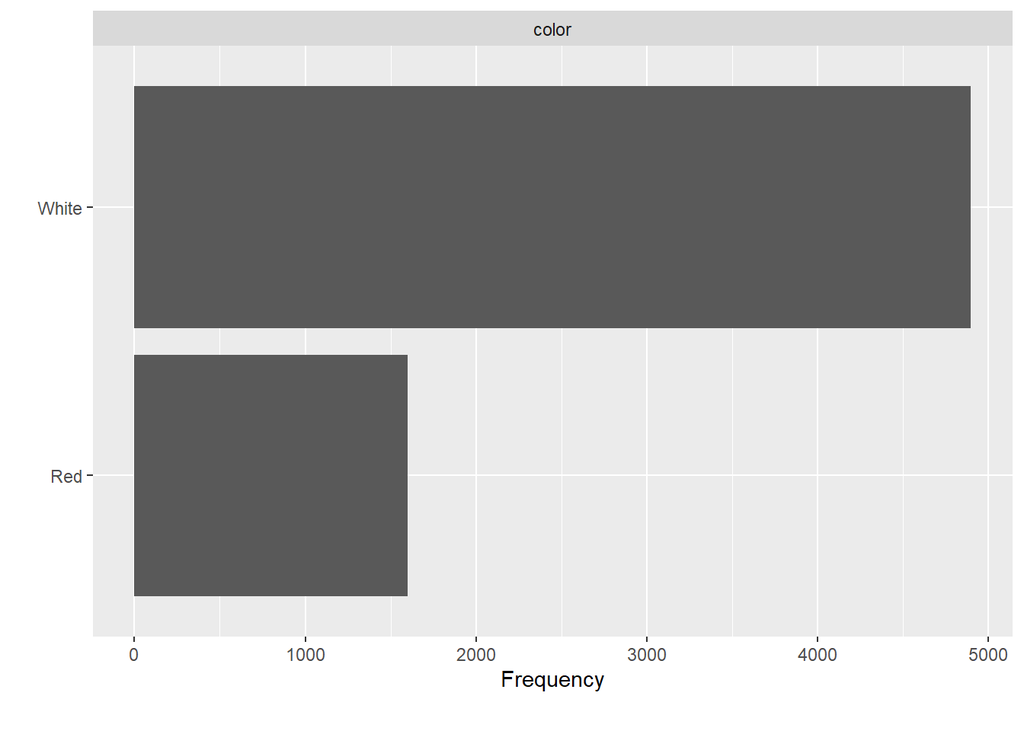

```r
# Plot barplot of all categorical variables
plot_bar(df)
```

Color, the only categorical variable in the dataset, has roughly three times as many white wine observations as it does red wine observations. This is an important note to keep in mind as an explanatory model may have a bias towards the rating quality of white wines rather than red wines.

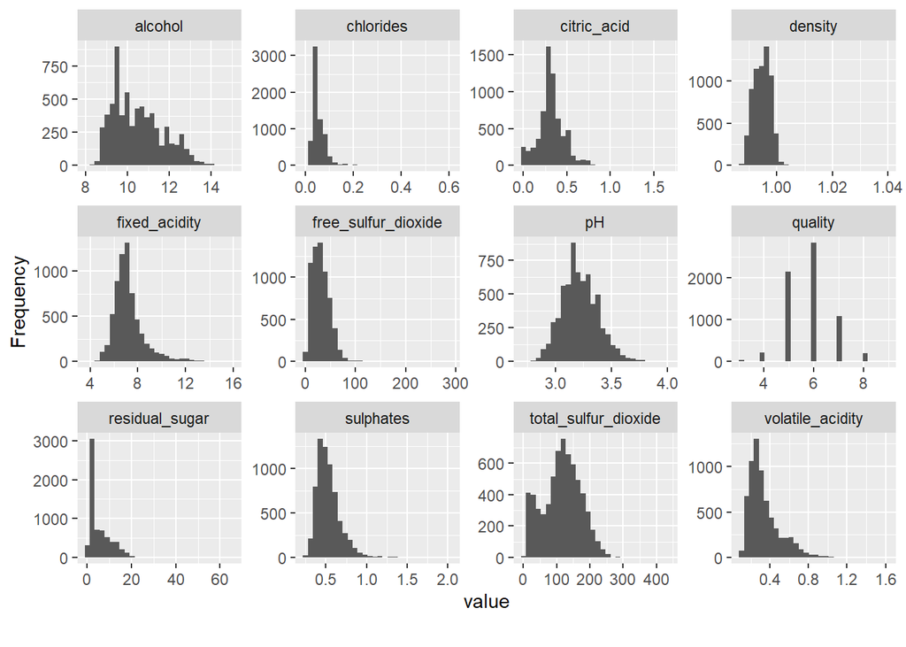

```r
# Plot histogram of all numeric variables
plot_histogram(df)
```

Looking at the histograms of all numeric variables in the dataset, two variables that have particularly concerning right skewness are the density and residual sugar. This indicates that they may have particularly influential outliers.

**Outlier Investigation**

Looking further into the right skewness for density and residual sugar, wine quality was plotted against the observations for both of these variables

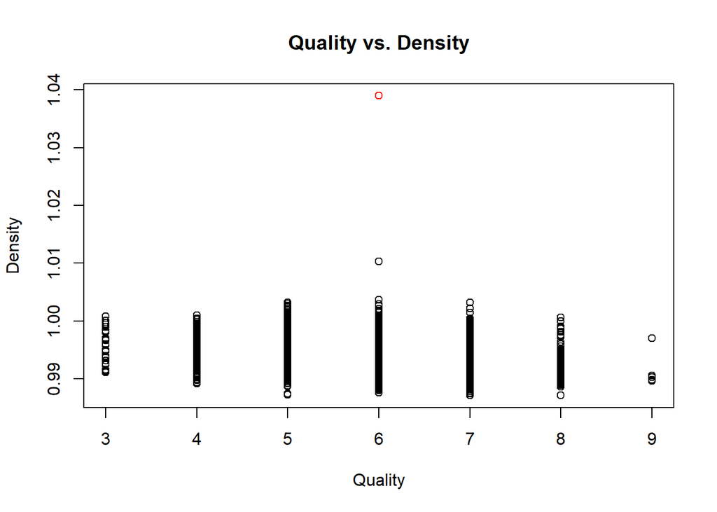

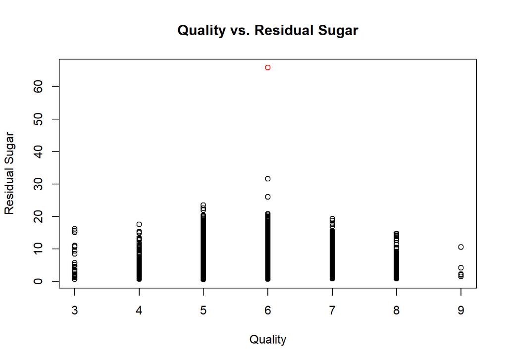

```r
# Investigate unusual columns
plot(df$quality, df$density,
     ylab = "Density",
     xlab = "Quality",
     main = "Quality vs. Density",
     col=ifelse(df$density > 1.03, "red", "black"))

plot(df$quality, df$residual_sugar,
     ylab = "Residual Sugar",
     xlab = "Quality",
     main = "Quality vs. Residual Sugar",
     col=ifelse(df$residual_sugar > 60, "red", "black"))
```

In both instances, there was one particularly influential observation (highlighted in red) that shared both the same unusual density and sugar content from the rest of the bottles.

```r
# Remove outliers from residual sugar and density

df_outlier <- which(df$residual_sugar > 60)

df_outlier %>%
  union(which(df$density > 1.03)) -> df_outlier

df = df[-df_outlier,]
```

This outlier was removed from the dataset.

## 3.4 Final Explanatory Model

For the final model, training and validation datasets were constructed. 60% of the data was used for training, and 40% of the data was used for validation.

Multi-linear regression was used to develop an explanatory model for both white and red “Vinho Verde” wines. The variables used in this final model are:

- Volatile acidity
- Free sulfur dioxide
- Alcohol content
- Color

This resulted in the following regression equation:

We can explain 26.2% of variation in wine quality while using the volatile acidity level, free sulfur dioxide level, alcohol content, and color as predictors in a linear model.

```r
# Calculate predicted values for validation set and transform
df.valid$quality_pred <- predict(df.reg, newdata=df.valid)
df.valid <- df.valid %>%
  mutate(quality_pred_adj = I(quality_pred^2))

# Compare RMSE calculation to caret package
rmse <- caret::RMSE(df.valid$quality_pred_adj, df.valid$quality)
```

The model has an overall RMSE of 0.73

### 3.4.1 Model Assumptions

Linear model assumptions were tested in order to ensure the integrity of the final model.

**Mean of Error Term**

The mean of the probability distribution of the error is $\approx 0$, therefore this assumption is passed.

**Variance of Error Term**

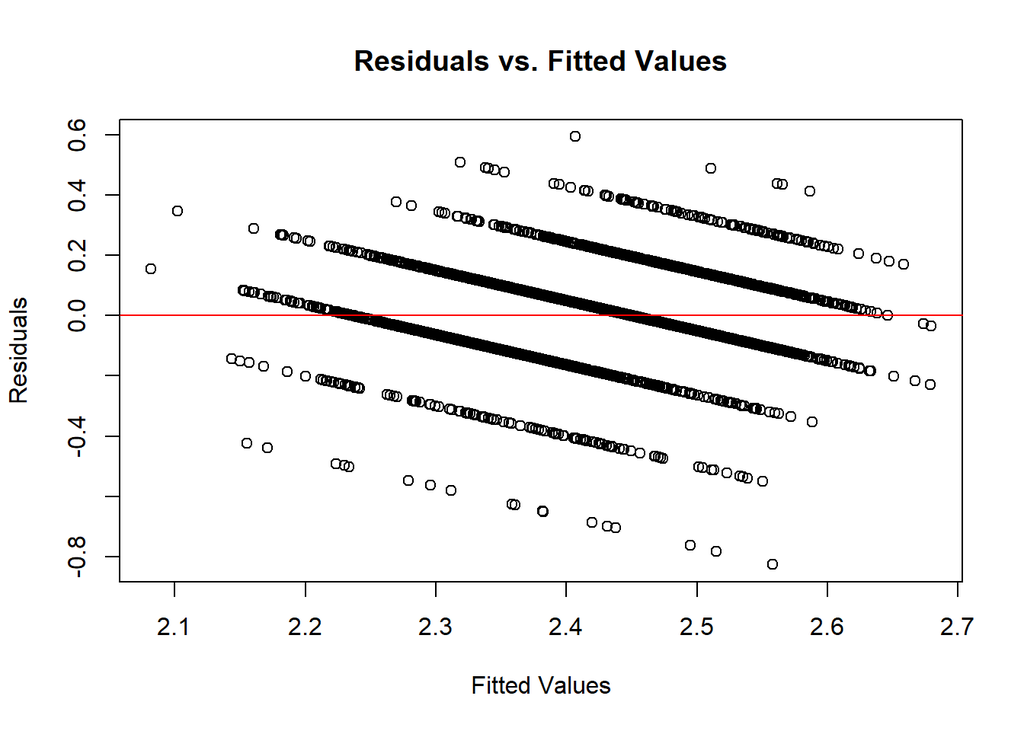

```r
plot(df.reg$fitted.values, df.reg$residuals,
     ylab = "Residuals",
     xlab = "Fitted Values",
     main = "Residuals vs. Fitted Values")
abline(0,0, col = "red")
```

The variance of the probability distribution of the error looks relatively scattered, so this assumption is passed. Note that since quality has a finite number of values, distinct streaks appear for each value of quality in the dataset.

**Normal Distribution of Error Term**

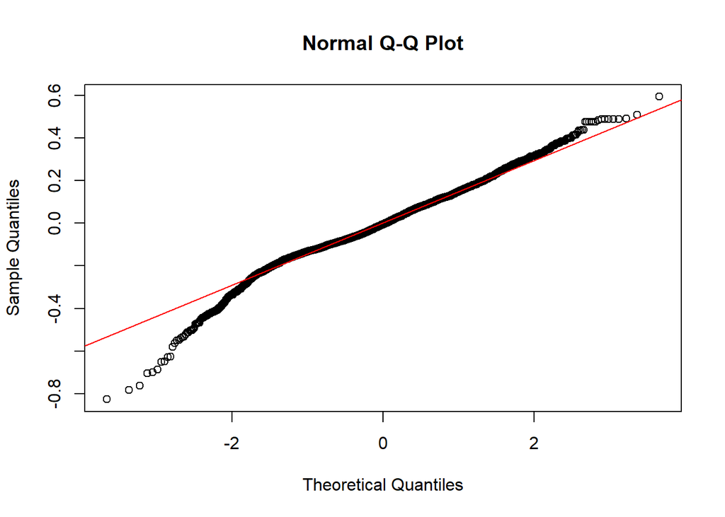

```r
qqnorm(df.reg$residuals)
qqline(df.reg$residuals, col = "red")
```

The QQ Plot curvature in the lower left and upper right corners indicates long tails on both the lower and upper ends of the wine quality.

Between this plot and the above residual plot, we can assume that the error is normally distributed.

**Independent Observations**

Additionally, we can assume that each of these observations are independent of each other as each one represents a separate bottle of wine.

### 3.4.2 Predictive Power

Since there are only 4 observations with a quality of 9, and no observations with a quality of 10, high quality prediction should be approached with caution. In order to illustrative the predictive power of the model, the quality of a white and red bottle were predicted.

```r
data.frame(
  volatile_acidity = 0.25,
  free_sulfur_dioxide = 30,
  alcohol = 8,
  color = "Red"
) -> prediction_frame

df.reg %>%
  predict(prediction_frame, interval="prediction") %>%
  `^`(2) -> predict1
```

The first example prediction was made on a bottle of wine with the following characteristics:

- Volatile Acidity: $0.25g(acetic\;acid)/dm^3$
- Free Sulfur Dioxide: $30mg/dm^3$
- Alcohol Content: 8%

One can predict with 95% confidence that a bottle with these characteristics will have a quality rating between 4 and 6.9

```r
data.frame(
  volatile_acidity = 0.3,
  free_sulfur_dioxide = 35,
  alcohol = 10.1,
  color = "White"
) -> prediction_frame

df.reg %>%
  predict(prediction_frame, interval="prediction") %>%
  `^`(2) -> predict2
```

The second example prediction was made on a bottle of wine with the following characteristics:

- Volatile Acidity: $0.3g(acetic\;acid)/dm^3$
- Free Sulfur Dioxide: $35mg/dm^3$
- Alcohol Content: 10.1%

One can predict with 95% confidence that a bottle with these characteristics will have a quality rating between 4.3 and 7.2

# 4 Conclusion

## 4.1 Value Proposition

This solution was developed to meet the needs of winery technicians who are actively involved in the wine production process. On a regular basis, they actively take measurements of each wine barrel to ensure the wine will be of an intended quality when it’s produced. These technicians also intend to receive the “Vinho Verde” certification for that respective wine batch.

Currently, the pain point in the process is the usage of excess resources making a wine batch that is of the wrong quality (i.e. too high or too low). The technicians are looking for a solution that assists with wine production and aligns with what an expert’s subjective wine rating will most likely be.

By having an indicator towards a wine batch’s objective quality, these technicians can maximize the likelihood of receiving a desirable subjective expert wine rating.

## 4.2 Solution

This solution takes the form of a multi-linear regression equation. The technician, who has a background in chemical engineering, can input the measurements they already take on a daily basis into this equation. It will then provide an estimate for the overall wine quality once a batch is completed and ready for an expert rating.

As a result of this equation, the winery is less likely to be caught off guard by a subjective expert wine rating (minimized quality deviation). Additionally, poor quality wine batches will be identified earlier in the production process to either remedy or abandon.

Please note that this solution was was reduced in scope to no longer include a shiny web app or separate red/white wine models. This was due to time constraints, but we feel that this solution still adequately estimates wine quality.

# References

Cortez, Paulo, António Cerdeira, Fernando Almeida, Telmo Matos, and José Reis. 2009. “Modeling Wine Preferences by Data Mining from Physicochemical Properties.” *Decision Support Systems* 47 (4): 547–53. https://doi.org/https://doi.org/10.1016/j.dss.2009.05.016.